# Porządkowanie liniowe i analiza skupień

Jakub Ignatik

10 grudnia 2018

# Rozdział I: Ranking obiektów

### Wprowadzenie

Celem tej części projektu będzie przedstawienie rankingu polskich miast najbardziej przyjaznych rowerzystom.  
**Dane:** Dane pochodzą z magazynu rowerowego “Rowertour” (11/2018), gdzie został przedstawiony ranking miast najbardziej przyjaznych rowerzystom. Jednak ranking tam przedstawiony jest dość subiektywny, biorąc pod uwagę opinie organizacji rowerowych (np. brak takiej opinii obniża maksymalną liczbę punktów do zdobycia za kategorię o 1/3), a także stosuje dla kategorii oceniającej łączną długość DIR skalę otwartą, przez co powstaje spora różnica pomiędzy miastami, rzutująca na ranking.  
Jeśli chodzi o ilość miast, dla których wykonywany będzie ranking, postanowiłem pozostawić oryginalną ich liczbę - 39, co nie odbiega sporo od wymienionej w zadaniu liczby 30.  
**Metodologia:** Zmuszony jestem ograniczyć liczbę zmiennych, których w danych można naliczyć dość sporo. Analizę ograniczę do drogowej infrastruktury rowerowej (DIR), w skład której wchodzą następujące zmienne (s - stymulanta, d - destymulanta):  
-*DIR.lacznie:* Łączna długość DIR (s)  
-*DIR.asfalt:* Długość DIR o powierzchni asfaltowej (s)  
-*DIR.kostka:* Długość DIR o powierzchni z kostki/płyt chodnikowych (d)  
-*DIR.inne:* Długość DIR o innej powierzchni (d)  
-*Pasy.ruchu:* Łączna długość pasów ruchu dla rowerów (s)  
-*Drogi.row.lacznie:* Łączna długość dróg dla rowerów (s)  
-*Drogi.row.asfalt:* Długość dróg dla rowerów o powierzchni asfaltowej (s)  
-*Ciagi.lacznie:* Łączna długość ciągów pieszo-rowerowych (d)  
-*Ciagi.asfalt:* Długość ciągów pieszo-rowerowych o powierzchni asfaltowej (s)  
Ranking wykonam trzema metodami: metodą Hellwiga, metodą standaryzowanych sum oraz metodą sumy rang.

### Wprowadzenie danych oraz ich obróbka

Oprócz zmiennych, które będą brać udział w tworzeniu rankingu (jednostka: km), wprowadzę też liczbę mieszkańców (w tys.) oraz długość dróg publicznych(w km).

```r
Bialystok <- c(297.3,426,124,103.6,19.6,0.8,0,102.2,87.4,21.8,16.2)
Bielsko_Biala <- c(171.5,589.1,30.2,26.2,3,1,0.73,15.7,15.7,13.7,12)
Bydgoszcz <- c(352.3,827.5,86.7,44.7,28.3,12,0.6,31.3,20.1,53.1,24.5)
Bytom <- c(168.4,211,15.5,9.7,4.9,0.3,0,4.3,4.3,7.3,1.8)
Chorzow <- c(109,137,51,38.1,12.9,0,0,5.5,5.5,12,5)
Czestochowa <- c(224.4,653,75.6,36.9,38,0.7,5.7,26.6,24.1,43.3,7.1)
Dabrowa_Gornicza <- c(121.1,398,30.8,22.9,7.9,0,2.5,15.3,13,10,4.4)
Elblag <- c(120.9,219.1,45.1,6.5,38.6,0,1,3.8,2.8,40.3,3.2)
Gdansk <- c(464.3,818.8,168.1,127.9,40.2,0,10.2,124.3,102,19,8.1)
Gdynia <- c(246.3,399.8,63.4,46,15.2,2.2,3,33.9,28.8,26.5,14.1)
Gliwice <- c(181.3,430,40.5,18.8,14.6,7.1,0,24.2,13.5,16.3,5.3)
Gorzow_Wlkp <- c(124.3,295,50,16.4,31.7,1.9,4.2,9.7,9,32.5,3.4)
Grudziadz <- c(92.1,235,58.1,16.6,40.3,1.1,2.8,28.3,12.6,24.4,4.05)
Kalisz <- c(101.6,311.6,47.3,22.1,25.2,0,3.8,0.9,0.4,42.8,15.5)
Katowice <- c(296.3,552,68,28,40,0,7,23,16,36,3)
Kielce <- c(196.8,380,52.8,26.3,19,7.5,1.7,30.6,23.8,22.2,2.5)
Koszalin <- c(107.7,230,77.8,41,34.7,2.2,0.55,38.9,26.1,39.9,14.8)
Krakow <- c(767.3,3135.2,165.4,149,16,0,17.7,110,104.5,NA,NA)
Lublin <-c(339.8,582.7,153.8,99.8,53.1,0.9,26.6,8,6.7,117.5,64.8)
Lodz <- c(690.4,1036.9,197.2,99.1,53.5,2.3,33.3,NA,NA,NA,NA)

Olsztyn <- c(173.1,346.2,68.9,28.3,30.6,10,1.5,52.9,26.3,16.5,0.5)
Opole <- c(128.1,403,85.8,32.5,53.9,1.3,1.4,13.2,7.9,70.9,23.1)
Plock <- c(120.8,273,63.2,54.4,5.5,0,1.6,59.9,54.4,1.7,0)
Poznan <- c(538.6,1053,232.1,126,NA,NA,16,98.2,70,85.6,40)
Radom <- c(214.6,332,79.4,71.3,7.1,0,7.8,57.3,54.3,13.4,11.4)
Ruda_Slaska <- c(138.3,261,27.8,10.6,16.5,0.7,4.5,20,9.4,3.7,0.8)
Rybnik <- c(139.1,445.2,38.5,22.2,12.3,4,4.3,9.4,5.1,22.5,10.5)
Rzeszow <- c(189.7,321.1,140.5,119.9,20.6,0,1.6,85.5,85.5,51,28)
Slupsk <- c(91.5,154.8,45.1,31,24.1,9.1,2.4,22.8,15.1,20,3.5)
Sosnowiec <- c(204,367,60,45,15,0,0,45,35,10,5)
Szczecin <- c(403.9,792.5,135.3,69.7,58.2,7.4,20.4,91.9,NA)
Tarnow <- c(109.6,366,67.1,10,57.1,0,2.75,23.4,5.2,43.7,4.8)
Torun <- c(202.6,481.7,111,89.5,18.3,3.2,2,90,76,19,13.5)
Tychy <- c(128.2,300,50,20.1,29.9,0,1.35,17.4,5.1,32.8,15)
Warszawa <- c(1764.6,2433.5,522,336,185,1,34.9,416.4,266.4,70.7,35.4)
Wroclawek <- c(111.8,219.9,54,15.7,32.4,5.8,0.78,11.5,8.6,42.6,7.1)
Wroclaw <- c(638.6,2209,345.7,185,97.7,63,29.5,175.4,108.7,74.7,44.1)
Zabrze <- c(174.3,220.2,23.6,18.5,5.2,0,1.3,7.7,7.2,14.6,10)
Zielona_Gora <- c(139.8,471,62.8,21.9,33.2,7.7,3,4.7,4.7,58.1,7.2)

dane <- rbind(Bialystok,Bielsko_Biala,Bydgoszcz,Bytom, Chorzow, Czestochowa, Dabrowa_Gornicza, Elblag, Gdansk, Gdynia, Gliwice, Gorzow_Wlkp, Grudziadz, Kalisz, Katowice, Kielce, Koszalin, Krakow, Lublin, Lodz, Olsztyn, Opole, Plock, Poznan, Radom, Ruda_Slaska, Rybnik, Rzeszow, Slupsk, Sosnowiec, Szczecin, Tarnow, Torun, Tychy, Warszawa, Wroclawek, Wroclaw, Zabrze, Zielona_Gora)
dane <- as.data.frame(dane)

colnames(dane) <-c("Ludzie","Dlugosc.drog","DIR.lacznie","DIR.asfalt","DIR.kostka","DIR.inne","Pasy.ruchu","Drogi.row.lacznie","Drogi.row.asfalt","Ciagi.lacznie","Ciagi.asfalt")
```

Jeśli chodzi o uzupełnianie brakujących obserwacji, których nie ma tak dużo, wykorzystam korelację. Pokażę to na przykładzie obliczania DIR z kostki/płyt chodnikowych dla Poznania. Na początku tworzę macierz korelacji, aby zobaczyć, która ze zmiennych jest wysoko korelowana ze zmienną DIR.kostka.

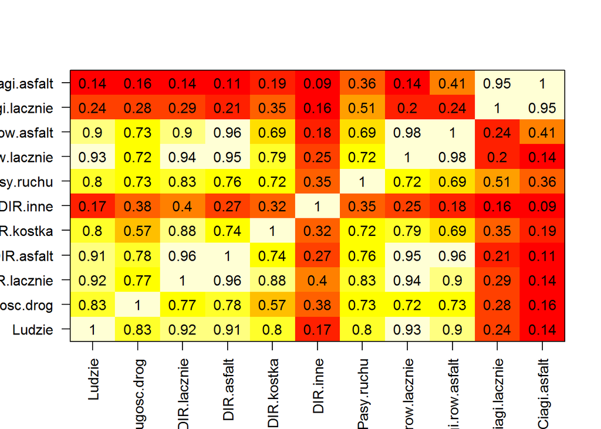

```r
COR <- cor(dane[,1:11], use = "pairwise.complete.obs")
image(x=seq(nrow(COR)), y=seq(ncol(COR)), z=cor(dane[,1:11], use = "pairwise.complete.obs"), axes=F, xlab="", ylab="")
text(expand.grid(x=seq(dim(COR)[1]), y=seq(dim(COR)[2])), labels=round(c(COR),2))
box()
axis(1, at=seq(nrow(COR)), labels = rownames(COR), las=2)
axis(2, at=seq(ncol(COR)), labels = colnames(COR), las=1)
```

Można zauważyć wysoką korelację między zmienną DIR.kostka a DIR.lacznie (0.88). Poznań posiada tę wartość, więc tworzę wykres, na którym zestawię te dwie wartości, a następnie wyrysuję linię modelu liniowego oraz zaznaczę wartość DIR.lacznie dla Poznania.

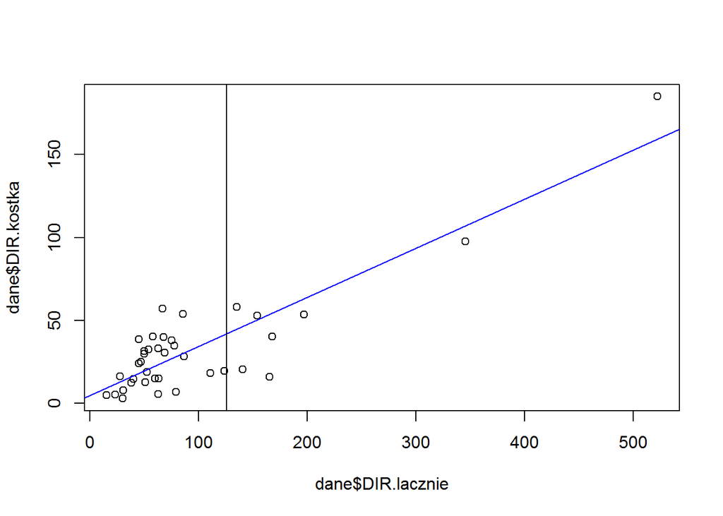

```r
plot(dane$DIR.lacznie,dane$DIR.kostka)
abline(lm(dane$DIR.kostka ~ dane$DIR.lacznie), col="blue")
abline(v=126)
```

Kolejnym krokiem jest użycie funkcji locator(), po której włączeniu mam możliwość zaznaczenia punktu na wykresie. Zaznaczam punkt przecięcia dwóch linii, następnie kończę funkcję, a ta w konsoli wypisuje koordynaty punktu. Wartość “y” wpisuję jako długość DIR z kostki dla miasta Poznań. Poniżej wypisuję uzupełnione wartości:

```r
dane["Poznan","DIR.kostka"] <- 86.7
#Dla DIR.inne posłużyłem się średnią, gdyż zachodzi zbyt niska korelacja
dane["Poznan","DIR.inne"] <- 19.6
dane["Lodz","Drogi.row.lacznie"] <- 134.4
dane["Szczecin","Drogi.row.asfalt"] <- 65.7
dane["Lodz","Drogi.row.asfalt"] <- 71.7

#Wstawiam średnią, zmienna posiada niską korelację z innymi zmiennymi. Wyjątek to Szczecin,
#który posiada brak tylko w jednej z tych dwóch wartości (te dwie zmienne są wysoko skorelowane)
dane[is.na(dane[,"Ciagi.lacznie"]) == TRUE,"Ciagi.lacznie"] <- round(mean(dane$Ciagi.lacznie, na.rm = TRUE),1)
dane["Szczecin","Ciagi.asfalt"] <- 5.8
dane[is.na(dane[,"Ciagi.asfalt"]) == TRUE,"Ciagi.asfalt"] <- round(mean(dane$Ciagi.asfalt, na.rm = TRUE),1)
```

Teraz, gdy dane są kompletne, należy poddać je transformacji, aby nie brać do tworzenia rankingu wartości bezwzględnych i nie faworyzować dużych miast. Większość zmiennych przekształcam jako wyliczenie, ile razy więcej udziału ma w DIR niż pozostałe zmienne wchodzące w jej skład.

```r
#dane[,3] - łączna długość DIR, dane[,2] - długość dróg publicznych
dane[,4] <- dane[,4]/(dane[,3]-dane[,4])
dane[,5] <- dane[,5]/(dane[,3]-dane[,5])
dane[,6] <- dane[,6]/(dane[,3]-dane[,6])
dane[,7] <- dane[,7]/(dane[,3]-dane[,7])
for (i in 1:nrow(dane)){
  if(dane[i,9] == dane[i,8]){
    dane[i,9] <- 1
  }
  else{
    dane[i,9] <- dane[i,9]/(dane[i,8]-dane[i,9])
  }
}
dane[,8] <- dane[,8]/(dane[,3]-dane[,8])
dane[,11] <- dane[,11]/(dane[,10]-dane[,11])
dane[,10] <- dane[,10]/(dane[,3]-dane[,10])
dane[,3] <- dane[,3]/dane[,2]
```

Po uzupełnieniu danych oraz ich przekształceniu można przejść do tworzenia rankingu.

### Metoda Hellwiga

Na początku poddam dane standaryzacji i stworzę ramkę danych, która będzie zawierać obliczenia dla rankingu metodą Hellwiga.

```r
danee <- dane
for (i in 1:ncol(danee)){
  danee[,i] <- (danee[,i] - mean(danee[,i]))/sd(danee[,i])
}

dane2 <- data.frame(matrix(NA,nrow=39,ncol=10))
```

Postanowiłem na dane nałożyć wagi. Ciężko byłoby ustalić je metodą ekspercką, gdyż zmiennych nie jest mało, a ja sam nie jestem specjalistą w zakresie infrastruktury rowerowej. Dlatego też za wagi posłużył mi współczynnik zmienności.

```r
wagi <- c(rep(NA, 9))
for (i in 1:9){
  wagi[i] <- sd(dane[,i])/mean(dane[,i])
}
suma_wag <- sum(wagi)
```

Policzę teraz odchylenia od wzorca dla każdej ze zmiennej. W moim zbiorze są 3 destymulanty: długość DIR z kostki i długość DIR z innej nawierzchni (najlepszy materiał na DIR to asfalt) oraz łączna długość ciągów pieszo-rowerowych (jest to najgorsza dla rowerzystów możliwość zrealizowania DIR).

```r
for (i in 1:nrow(dane)){
  dane2[i,1] <- (wagi[1]/suma_wag)*(danee[i,3] - max(danee[,3]))^2
  dane2[i,2] <- (wagi[2]/suma_wag)*(danee[i,4] - max(danee[,4]))^2
  dane2[i,3] <- (wagi[3]/suma_wag)*(danee[i,5] - min(danee[,5]))^2
  dane2[i,4] <- (wagi[4]/suma_wag)*(danee[i,6] - min(danee[,6]))^2
  dane2[i,5] <- (wagi[5]/suma_wag)*(danee[i,7] - max(danee[,7]))^2
  dane2[i,6] <- (wagi[6]/suma_wag)*(danee[i,8] - max(danee[,8]))^2
  dane2[i,7] <- (wagi[7]/suma_wag)*(danee[i,9] - max(danee[,9]))^2
  dane2[i,8] <- (wagi[8]/suma_wag)*(danee[i,10] - min(danee[,10]))^2
  dane2[i,9] <- (wagi[9]/suma_wag)*(danee[i,11] - max(danee[,11]))^2
  dane2[i,10] <- sqrt(sum(dane2[i,1:9]))
}
```

W kolejnym kroku policzę współczynnik Hellwiga oraz przedstawię finalny ranking.

```r
d0 <- mean(dane2[,10]) + 2*sd(dane2[,10])
dane2[,10] <- 1 - dane2[,10]/d0
rownames(dane2) <- c("Bialystok", "Bielsko_Biala", "Bydgoszcz", "Bytom", "Chorzow", "Czestochowa", "Dabrowa_Gornicza", "Elblag", "Gdansk", "Gdynia", "Gliwice", "Gorzow_Wlkp", "Grudziadz", "Kalisz", "Katowice", "Kielce", "Koszalin", "Krakow", "Lublin", "Lodz", "Olsztyn", "Opole", "Plock", "Poznan", "Radom", "Ruda_Slaska", "Rybnik", "Rzeszow", "Slupsk", "Sosnowiec", "Szczecin", "Tarnow", "Torun", "Tychy", "Warszawa", "Wroclawek", "Wroclaw", "Zabrze", "Zielona_Gora")

colnames(dane2)[10] <- "Hellwig"

dane2 <- dane2[rev(order(dane2$Hellwig)),]
print(dane2[,"Hellwig", drop=FALSE])
```

```
##                      Hellwig
## Radom             0.45556984
## Plock             0.44770546
## Bialystok         0.36145069
## Torun             0.33207508
## Warszawa          0.27030927
## Gdansk            0.26563203
## Krakow            0.26465150
## Rzeszow           0.25438889
## Zabrze            0.24482502
## Bielsko_Biala     0.24327622
## Lublin            0.23512250
## Lodz              0.22722831
## Sosnowiec         0.22343596
## Gdynia            0.21850772
## Szczecin          0.21661956
## Dabrowa_Gornicza  0.19783065
## Ruda_Slaska       0.19730827
## Poznan            0.19545417
## Chorzow           0.18319750
## Koszalin          0.18245619
## Gorzow_Wlkp       0.18153996
## Czestochowa       0.17394029
## Wroclaw           0.17358386
## Olsztyn           0.16783979
## Grudziadz         0.16125908
## Slupsk            0.15985921
## Rybnik            0.15223646
## Katowice          0.15214303
## Kielce            0.14033947
## Tychy             0.13974896
## Wroclawek         0.11859905
## Opole             0.11345808
## Bydgoszcz         0.11078852
## Bytom             0.10171117
## Gliwice           0.09891091
## Tarnow            0.09832424
## Kalisz            0.06704587
## Elblag            0.03426539
## Zielona_Gora     -0.01875511
```

Metoda Hellwiga na najlepsze miasta pod względem DIR wskazała Radom, Płock oraz Białystok. Najgorsze miasta według tej metody to Zielona Góra, Elbląg oraz Kalisz.

### Metoda standaryzowanych sum

Na początku zamieniam destymulanty na stymulanty. Do modelu wykorzystam ten sam system wag, co w metodzie Hellwiga, więc nie wprowadzam go ponownie. Dane zestandaryzuję.

```r
dane3 <- dane
dane3[,5] <- -dane[,5]
dane3[,6] <- -dane[,6]
dane3[,10] <- -dane[,10]

#Usuwam liczbę ludności i długość dróg publicznych
dane3 <- dane3[,-c(1,2)]

for (i in 1:ncol(dane3)){
  dane3[,i] <- (dane3[,i] - mean(dane3[,i]))/sd(dane3[,i])
}
```

Sumuję rangi, a następnie je standaryzuję. Zaraz potem przedstawię ranking miast.

```r
for (i in 1:nrow(dane3)){
  dane3[i,10] <- sum(dane3[i,1:9]*(wagi/suma_wag))
}

for (i in 1:nrow(dane3)){
  dane3[i,11] <- (dane3[i,10] - min(dane3[,10]))/max(dane3[,10] - min(dane3[,10]))
}

colnames(dane3)[11] <- "Wskaznik"
dane3 <- dane3[rev(order(dane3$Wskaznik)),]
print(dane3[,"Wskaznik", drop=FALSE])
```

```
##                   Wskaznik
## Radom            1.0000000
## Plock            0.9329232
## Krakow           0.7445731
## Bialystok        0.7127771
## Rzeszow          0.6521052
## Torun            0.6440990
## Bielsko_Biala    0.6391500
## Lublin           0.5983680
## Lodz             0.5945599
## Gdansk           0.5817719
## Zabrze           0.5769019
## Szczecin         0.5736728
## Warszawa         0.5701053
## Ruda_Slaska      0.5187952
## Chorzow          0.5178258
## Sosnowiec        0.5019062
## Dabrowa_Gornicza 0.4993144
## Gdynia           0.4901763
## Koszalin         0.4539749
## Gorzow_Wlkp      0.4491218
## Czestochowa      0.4449434
## Poznan           0.4431357
## Katowice         0.4162249
## Grudziadz        0.4031335
## Wroclaw          0.3837400
## Rybnik           0.3762856
## Slupsk           0.3600616
## Tychy            0.3508209
## Olsztyn          0.3499993
## Kielce           0.3166564
## Bytom            0.3125031
## Tarnow           0.2785483
## Opole            0.2723015
## Wroclawek        0.2573665
## Bydgoszcz        0.2554086
## Gliwice          0.2344035
## Kalisz           0.2043919
## Elblag           0.1199956
## Zielona_Gora     0.0000000
```

Można zauważyć, że nie zmienił się koniec rankingu. Miasta z najgorszą DIR to wciąż Zielona Góra, Elbląg oraz Kalisz. Zmieniła się nieco pierwsza trójka: na trzecim miejscu zamiast Białegostoku znalazł się Kraków.

### Metoda sumy rang

Na początku zamieniam stymulanty na destymulanty i standaryzuję wszystkie zmienne, tworzę także ramkę danych na rangi.

```r
dane5 <- dane
dane5[,c(1:4,7:9,11)] <- -dane5[,c(1:4,7:9,11)]

for (i in 1:ncol(dane5)){
  dane5[,i] <- (dane5[,i] - mean(dane5[,i]))/sd(dane5[,i])
}

dane4 <- data.frame(matrix(NA,nrow=39,ncol=9))

rownames(dane4) <- c("Bialystok","Bielsko_Biala","Bydgoszcz","Bytom", "Chorzow", "Czestochowa", "Dabrowa_Gornicza", "Elblag", "Gdansk", "Gdynia", "Gliwice", "Gorzow_Wlkp", "Grudziadz", "Kalisz", "Katowice", "Kielce", "Koszalin", "Krakow", "Lublin", "Lodz", "Olsztyn", "Opole", "Plock", "Poznan", "Radom", "Ruda_Slaska", "Rybnik", "Rzeszow", "Slupsk", "Sosnowiec", "Szczecin", "Tarnow", "Torun", "Tychy", "Warszawa", "Wroclawek", "Wroclaw", "Zabrze", "Zielona_Gora")
```

Przed wyświetleniem rankingu należy jeszcze zestandaryzować zmienne oraz utworzyć zmienną pozwalającą na useregowanie miast.

```r
for (i in 1:ncol(dane4)){
  dane4[,i] <- rank(dane5[,i+2])
}

dane4[,10] <- NULL

for (i in 1:nrow(dane4)){
  dane4[i,10] <- mean(as.numeric(dane4[i,1:9]))
}

colnames(dane4)[10] <- "Suma rang"

dane4 <- dane4[order(dane4$'Suma rang'),]
print(dane4[,"Suma rang", drop=FALSE])
```

```
##                  Suma rang
## Radom             5.277778
## Bialystok        10.222222
## Plock            10.500000
## Gdansk           10.722222
## Torun            11.555556
## Krakow           11.777778
## Rzeszow          13.166667
## Warszawa         13.444444
## Sosnowiec        13.833333
## Zabrze           15.388889
## Dabrowa_Gornicza 15.500000
## Lublin           16.333333
## Gdynia           16.444444
## Lodz             16.611111
## Wroclaw          18.333333
## Chorzow          18.388889
## Szczecin         18.555556
## Poznan           18.666667
## Bielsko_Biala    18.888889
## Koszalin         21.222222
## Slupsk           21.555556
## Ruda_Slaska      21.777778
## Czestochowa      22.444444
## Rybnik           22.777778
## Katowice         23.500000
## Kielce           23.666667
## Olsztyn          25.000000
## Grudziadz        25.333333
## Bydgoszcz        25.555556
## Tychy            25.611111
## Gorzow_Wlkp      25.777778
## Kalisz           26.166667
## Gliwice          26.444444
## Bytom            26.555556
## Opole            27.555556
## Wroclawek        27.888889
## Elblag           28.055556
## Tarnow           28.277778
## Zielona_Gora     31.222222
```

W pierwszej trójce ponownie znalazła się cała czołówka z rankingu wykonanego metodą Hellwiga, chociaż kolejność jest nieco inna. Na pierwszym miejscu znów jest Radom, ale drugie miejsce zajmuje Białystok, a trzecie Płock. Najgorsze miasta w rankingu to Zielona Góra, Tarnów (po raz pierwszy w ostatniej trójce) oraz Elbląg.

### Podsumowanie

# Rozdział II: Grupowanie obiektów

### Wprowadzenie

Celem tej części projektu będzie przedstawienie rankingu polskich miast najbardziej przyjaznych rowerzystom.  
**Dane:** Dane, podobnie jak w poprzedniej części, pochodzą z magazynu rowerowego “Rowertour” (11/2018), gdzie został przedstawiony ranking miast najbardziej przyjaznych rowerzystom. Jeśli chodzi o ilość miast, dla których wykonywany będzie ranking, postanowiłem pozostawić oryginalną ich liczbę - 39, co nie odbiega sporo od wymienionej w zadaniu liczby 30. Zestaw danych został wprowadzony już w poprzedniej części projektu, tam też został poddany transformacji, dlatego w tej części projektu nie będę robił tego ponownie.  
**Metodologia:** Zmuszony jestem ograniczyć liczbę zmiennych, których w danych można naliczyć dość sporo. Analizę ograniczę do drogowej infrastruktury rowerowej (DIR), w skład której wchodzą następujące zmienne (s - stymulanta, d - destymulanta):  
-*DIR.lacznie:* Łączna długość DIR (s)  
-*DIR.asfalt:* Długość DIR o powierzchni asfaltowej (s)  
-*DIR.kostka:* Długość DIR o powierzchni z kostki/płyt chodnikowych (d)  
-*DIR.inne:* Długość DIR o innej powierzchni (d)  
-*Pasy.ruchu:* Łączna długość pasów ruchu dla rowerów (s)  
-*Drogi.row.lacznie:* Łączna długość dróg dla rowerów (s)  
-*Drogi.row.asfalt:* Długość dróg dla rowerów o powierzchni asfaltowej (s)  
-*Ciagi.lacznie:* Łączna długość ciągów pieszo-rowerowych (d)  
-*Ciagi.asfalt:* Długość ciągów pieszo-rowerowych o powierzchni asfaltowej (s)

### Grupowanie podziałowe

Grupowanie podziałowe pozwoli na zbadanie, które z miast mają zbliżoną do siebie drogową infrastrukturę rowerową. Może się okazać, że miasta będą się grupować wg ich wielkości, co byłoby słabym rozwiązaniem. Mam nadzieję, że przekształcenie danych, które dokonałem w poprzedniej części, wpłynie pozytywnie na rozróżnienie miast przy grupowaniu.  
Zanim wykonam grupowanie podziałowe, zbadam, czy dane nadają się do analizy skupień. W tym celu jeszcze raz narysuję macierz korelacji. Aby zobaczyć, czy nie zachodzi współliniowość, ponownie narysuję macierz korelacji.

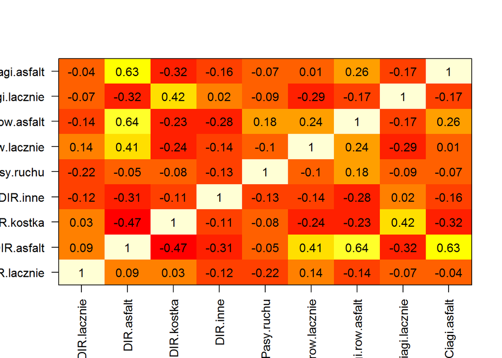

```r
#Usunięcie z danych zmiennych dotyczących liczby ludności oraz długości dróg publicznych - z tymi danymi miasta przyporządkowałoby pod względem ich wielkości
dane <- dane[,-c(1,2)]

COR <- cor(dane[,1:9])
image(x=seq(nrow(COR)), y=seq(ncol(COR)), z=cor(dane[,1:9]), axes=F, xlab="", ylab="")
text(expand.grid(x=seq(dim(COR)[1]), y=seq(dim(COR)[2])), labels=round(c(COR),2))
box()
axis(1, at=seq(nrow(COR)), labels = rownames(COR), las=2)
axis(2, at=seq(ncol(COR)), labels = colnames(COR), las=1)
```

W żadnym przypadku nie zachodzi nierówność |r| > 0.9. Ma na to wpływ przetransformowanie zmiennych, gdyż dla surowych danych takich korelacji było dość sporo. Pozostaje zbadać jeszcze współczynnik zmienności.

```r
for (i in 1:9){
  print(paste(colnames(dane)[i], ": ", (sd(dane[,i])/mean(dane[,i]))*100, sep=''))
}
```

```
## [1] "DIR.lacznie: 46.6063910578323"
## [1] "DIR.asfalt: 101.727373895483"
## [1] "DIR.kostka: 130.242712145335"
## [1] "DIR.inne: 143.910014997636"
## [1] "Pasy.ruchu: 93.6747109955247"
## [1] "Drogi.row.lacznie: 167.880415360058"
## [1] "Drogi.row.asfalt: 116.409170808251"
## [1] "Ciagi.lacznie: 166.767130088272"
## [1] "Ciagi.asfalt: 147.821429830403"
```

Również i ten warunek jest spełniony, dla żadnej ze zmiennych współczynnik nie spada poniżej 10%.  
Założenia są spełnione, więc poddam teraz dane normalizacji, do czego wykorzystam standaryzację.

```r
for (i in 1:ncol(dane)){
  dane[,i] <- (dane[,i] - mean(dane[,i]))/sd(dane[,i])
}
```

Sprawdzić należy, czy nie ma wartości odstających (<-3 lub >3).

```r
summary(dane)
```

```
##   DIR.lacznie        DIR.asfalt        DIR.kostka         DIR.inne
##  Min.   :-1.5517   Min.   :-0.9102   Min.   :-0.6924   Min.   :-0.6949
##  1st Qu.:-0.7613   1st Qu.:-0.6809   1st Qu.:-0.5113   1st Qu.:-0.6949
##  Median :-0.1676   Median :-0.4850   Median :-0.3337   Median :-0.4858
##  Mean   : 0.0000   Mean   : 0.0000   Mean   : 0.0000   Mean   : 0.0000
##  3rd Qu.: 0.5304   3rd Qu.: 0.3047   3rd Qu.: 0.1368   3rd Qu.: 0.3248
##  Max.   : 2.9240   Max.   : 2.9472   Max.   : 3.9281   Max.   : 2.7398
##    Pasy.ruchu      Drogi.row.lacznie Drogi.row.asfalt  Ciagi.lacznie
##  Min.   :-1.0675   Min.   :-0.5891   Min.   :-0.7991   Min.   :-1.14834
##  1st Qu.:-0.7700   1st Qu.:-0.4494   1st Qu.:-0.6493   1st Qu.:-0.49664
##  Median :-0.2131   Median :-0.2586   Median :-0.4314   Median :-0.33544
##  Mean   : 0.0000   Mean   : 0.0000   Mean   : 0.0000   Mean   : 0.00000
##  3rd Qu.: 0.4658   3rd Qu.: 0.1218   3rd Qu.: 0.2506   3rd Qu.:-0.01533
##  Max.   : 2.4943   Max.   : 5.5222   Max.   : 3.1256   Max.   : 3.91109
##   Ciagi.asfalt
##  Min.   :-0.67649
##  1st Qu.:-0.53961
##  Median :-0.28315
##  Mean   : 0.00000
##  3rd Qu.: 0.01728
##  Max.   : 4.21377
```

Okazuje się, że istnieją outliery (zmienne DIR.kostka, Drogi.row.lacznie, Drogi.row.asfalt, Ciagi.lacznie oraz Ciagi.asfalt). Postanowiłem jednak nic z nimi nie robić. Dane przedstawiają DIR w wybranych miastach i naturalnym jest, że któreś miasto może być w jednej cesze znacznie lepsze lub gorsze względem innych i daleko odstawać na tym polu (np. przypadek Zielonej Góry w I części projektu).  
Wykonam teraz grupowanie podziałowe trzema metodami: metodą k-średnich, algorytmem PAM (opartym o metodę k-medoid) oraz algorytmem CLARA (oparty również o metodę k-medoid, bazujący jednak na reprezentatywnej próbie).

## Metoda k-średnich

**UWAGA!** Nie wiem dlaczego, ale podczas tworzenia pliku HTML wykres ten uległ zmianie i nie mogę go przywrócić do porządku. Za każdym razem inaczej wykonuje porządkowanie. W ostatecznym wyniku jest dokładnie ten sam kod i daje on właściwy rezultat, więc komentarz pod niżej wykonanym wykresem odnosi się do wykresu wykonanego później, przy podaniu najlepszego wyniku.

Liczbę skupień na podstawie prób ustaliłem na liczbę 4, która moim zdaniem najlepiej ukazuje różnice między miastami: grupy nie przecinają się, łatwo jest o interpretację.

```r
library(factoextra)
```

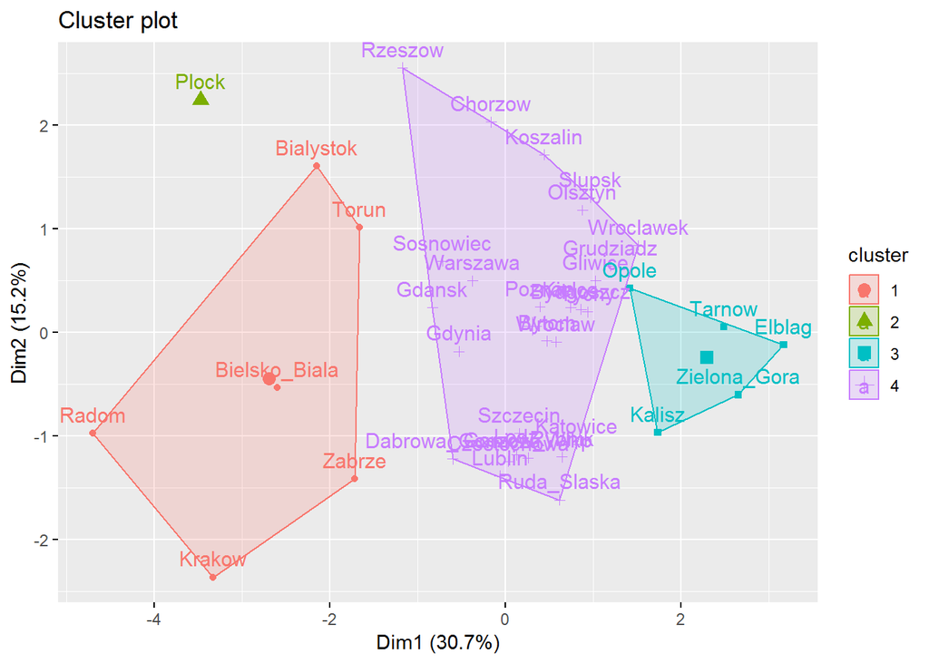

```r
xx <- kmeans(dane, 4, iter.max = 10)
fviz_cluster(xx, data = dane)
```

Metoda ta dobrze komponuje się z rankingiem wykonanym przeze mnie w pierwszym rozdziale. Wykres dobrze przedstawia zróżnicowanie miast.

## Algorytm PAM

W przypadku odległości euklidesowej, za najlepszą liczbę skupień ustaliłem liczbę 5, bo przy liczbie 4 powstaje zbyt duża grupa, w której skład wchodzi grupa czerwona i zielona.

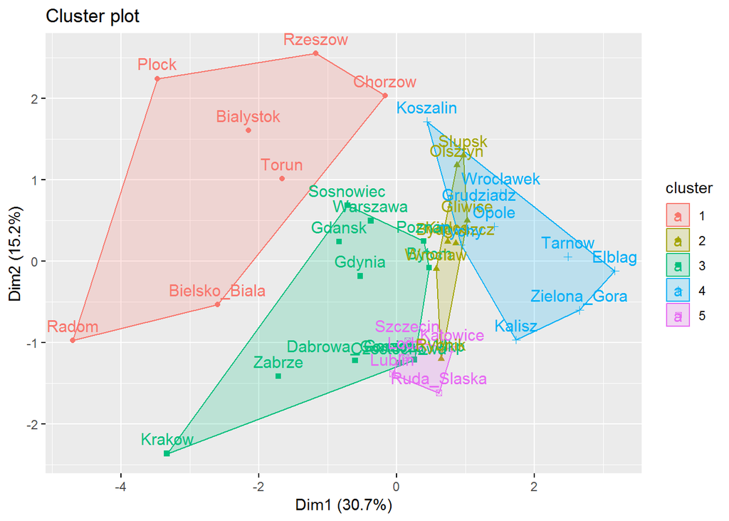

```r
library(cluster)
xx <- pam(dane, 5, metric = "euclidean")
fviz_cluster(xx, data = dane)
```

Wykres jest mniej czytelny niż jego poprzednik, wydaje się, że grupa fioletowa oraz oliwkowa są niepotrzebne, gdyż nie wydają się być odrębne od reszty. Grupy te jednak utrzymają się bez względu na to, jaką liczbę da się liczbę do algorytmu.  
W przypadku odległości miejskiej, wróciłem do liczby 4, gdyż liczba 5 jest zbyt duża, wykres jest mniej czytelny.

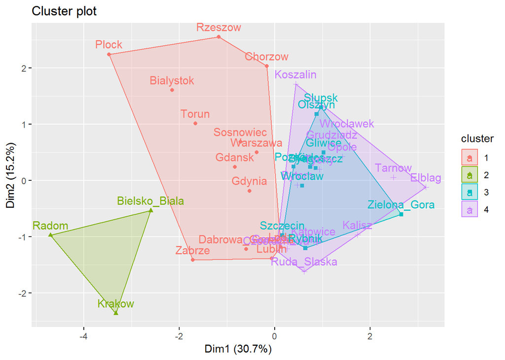

```r
xx <- pam(dane, 4, metric = "manhattan")
fviz_cluster(xx, data = dane)
```

Grupa fioletowa zawiera grupę niebieską, co nie wygląda przejrzyście. Dobrze z kolei zostały rozdzielone miasta w dolnym lewym rogu.

## Algorytm CLARA

Podobnie jak przy algorytmie PAM, tutaj też ustawiłem liczbę 5. Liczbę reprezentatywnej próby ustaliłem na 20, gdyż od 25-30 wykres dla tego algorytmu wygląda identycznie jak wykres dla algorytmu PAM.

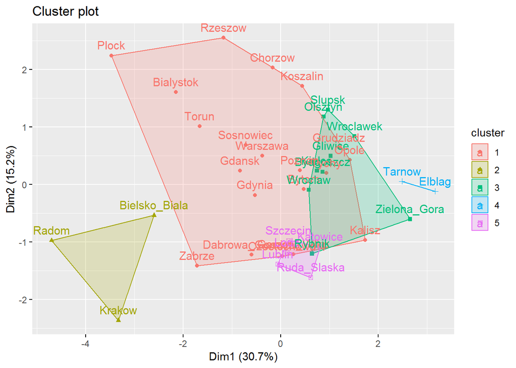

```r
xx <- clara(dane, 5, metric = "euclidean", samples = 5, sampsize = 20)
fviz_cluster(xx, data = dane)
```

Niepokoi przemieszanie grup fioletowej, czerwonej oraz zielonej. Całkiem sensowne wydają się być grupa oliwkowa oraz grupa niebieska.  
Dla odległości miejskiej najlepiej prezentuje się liczba 3, chociaż klastry są i tak przemieszane i trudno jest o przejrzystość wykresu.

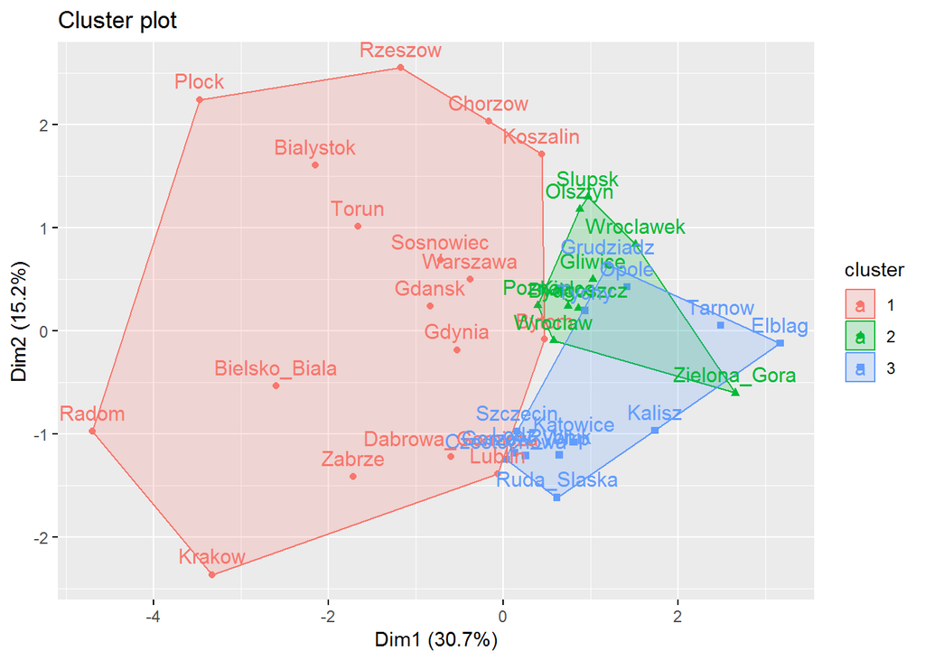

```r
xx <- clara(dane, 3, metric = "manhattan", samples = 5, sampsize = 20)
fviz_cluster(xx, data = dane)
```

## Podobieństwa i różnice

Na pierwszy rzut oka widać, że dla każdej z metod ustaliłem inną liczbę grup. Wynika to stąd, że każdy algorytm bazuje na czymś innym, więc trudno o z góry określoną liczbę, która najlepiej zadziała dla wszystkich algorytmów. Problemem jest też czytelność. Są wykresy, z których ciężko jest wyczytać, do której grupy należy miasto.  
Za najlepsze metody dla moich danych uważam metodę k-średnich oraz algorytm PAM z odległością euklidesową. Finalnie do analizy zdecydowałem się wziąć metodę k-średnich.

## Omówienie ostatecznego wyniku

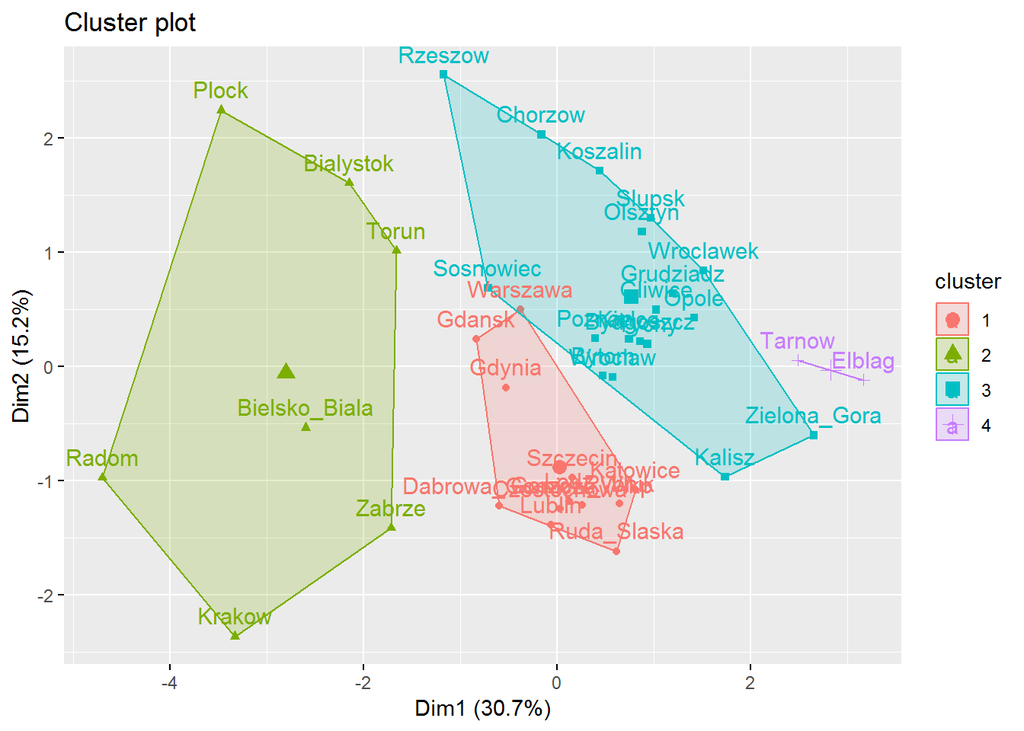

```r
xx <- kmeans(dane, 4, iter.max = 10)
fviz_cluster(xx, data = dane)
```

```r
podsumowanie <- data.frame(matrix(NA, nrow = 9, ncol = 4))
for (i in 1:4){
  for (j in 1:9){
    podsumowanie[j,i] <- lapply(dane[names(which(xx$cluster == i)),], mean)[[j]]
  }
  round(podsumowanie[,i],2)
}
colnames(podsumowanie) <- c(1:4)
rownames(podsumowanie) <- colnames(dane)
print(podsumowanie)
```

```
##                             1          2           3          4
## DIR.lacznie       -0.32845510 -0.1538432  0.26669695  0.1089094
## DIR.asfalt        -0.31355708  1.7044525 -0.35283593 -0.9087180
## DIR.kostka        -0.15633585 -0.6459454 -0.07099006  3.8377346
## DIR.inne          -0.35062299 -0.5581778  0.52802655 -0.6948787
## Pasy.ruchu         1.02031449 -0.2008981 -0.54536370 -0.5104703
## Drogi.row.lacznie -0.10662209  1.0062902 -0.26581833 -0.4899182
## Drogi.row.asfalt   0.07262882  1.3497294 -0.51381673 -0.5354752
## Ciagi.lacznie     -0.31418145 -0.4188737  0.23091760  1.2728884
## Ciagi.asfalt      -0.27956387  1.3709710 -0.27968262 -0.6038716
```

**Pierwsza grupa:** Dość dobra infrastruktura, jednak najmniej rozwinięta w stosunku do wielkości całego miasta: słabo rozwinięta DIR, jeśli chodzi o jej łączną długość; duży udział pasów ruchu w ogólnej infrastrukturze rowerowej; mały udział ciągów pieszo-rowerowych w DIR.  
**Druga grupa:** Najlepsza DIR, chociaż niezbyt rozwinięta wielkościowo - udział dróg z asfaltu jest tu największy, mało jest dróg z kostki i innych surowców; dużo dróg rowerowych (w tym także tych asfaltowych); mało ciągów pieszo-rowerowych (jeśli się takie pojawiają, są często wykonane z asfaltu).  
**Trzecia grupa:** Najlepiej rozwinięta wielkościowo DIR, jednak o niezbyt dobrej jakości; największy udział dróg z innego surowca w DIR; najmniejszy udział pasów ruchu i dość mała długość dróg rowerowych, które zastępowane są przez ciągi pieszo-rowerowe.  
**Czwarta grupa:** Obejmuje tylko 2 miasta, posiadają one najsłabszą jakościowo DIR; najmniej dróg z asfaltu i duża ilość dróg z kostki, a to zapewne z powodu największego udziału ciągów pieszo-rowerowych w DIR; najmniejsza długość dróg rowerowych

Podsumowując, grupy można opisać następująco:  
**Pierwsza grupa:** Dość dobre warunki jazdy, jednak zdecydowanie za mało rozwinięta infrastruktura.  
**Druga grupa:** Najlepsze warunki do jazdy, jednak nie za bardzo jest gdzie pojeździć.  
**Trzecia grupa:** Niezbyt dobre warunki jazdy, za to można bezproblemowo poruszać się rowerem po całym mieście.  
**Czwarta grupa:** Najgorsze warunki jazdy, jednak można rowerem zwiedzić większy kawałek miasta.  
To, jaka grupa jest najlepsza, zależy od naszych preferencji, jednak najbardziej optymalne warunki jazdy panują moim zdaniem w miastach z grupy trzeciej. Należy pamiętać, że gorsza jakość infrastruktury nie oznacza, że drogi są pełne dziur, a krawężniki są bardzo wysokie - gorszą infrastrukturą z punktu widzenia całości DIR są np. ciągi pieszo-rowerowe, które jednak same w sobie nie są tak złym rozwiązaniem lda rekreacyjnej jazdy.

### Grupowanie hierarchiczne

Zajmę się teraz grupowaniem hierarchicznym, które, tak jak i grupowanie podziałowe, pozwoli na zbadanie, które z miast mają zbliżoną do siebie drogową infrastrukturę rowerową. W poprzedniej części odeszły obawy dotyczące tego, że miasta grupować się będą względem wielkości. Zostały również sprawdzone założenia dobrego grupowania, a dane zostały zestandaryzowane. Tym samym można pominąć tą część i przystąpić od razu do grupowania hierarchicznego.  
Na początku wybiorę standardową funkcję odległości - odległość euklidesową, a następnie stworzę dendogramy dla kilku metod.

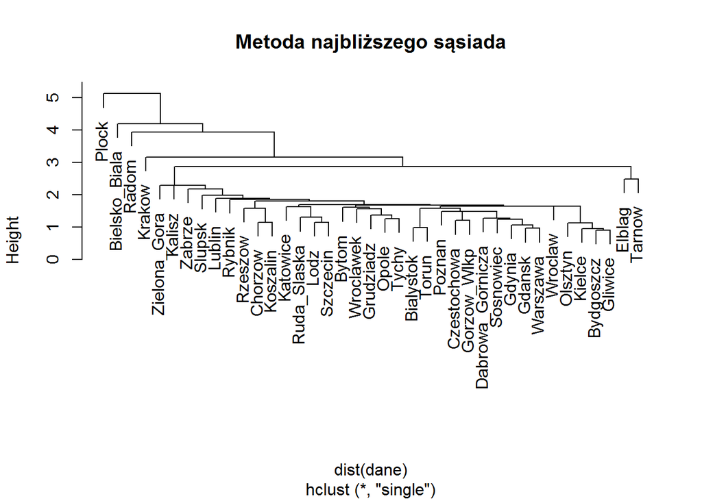

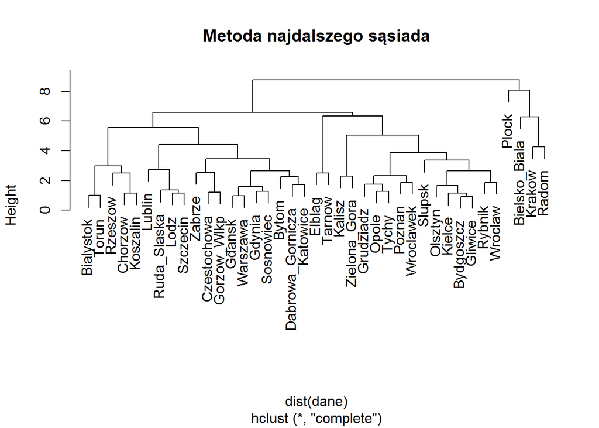

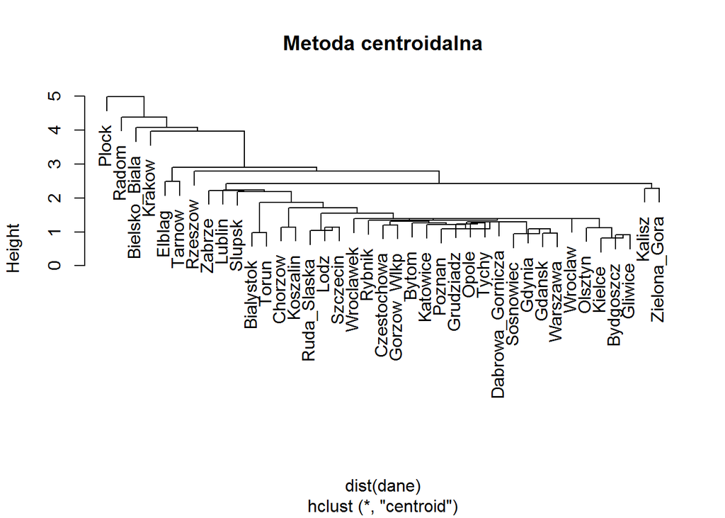

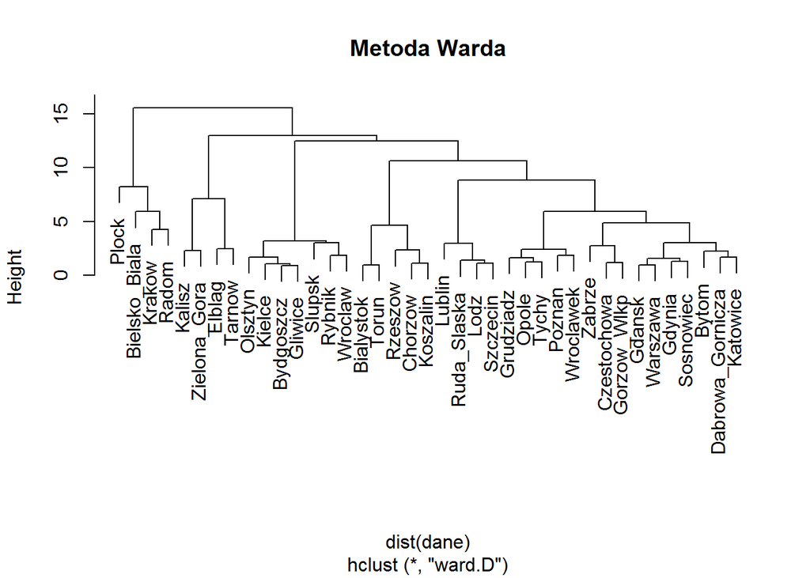

```r
plot(hclust(dist(dane),"single"), main = "Metoda najbliższego sąsiada")
plot(hclust(dist(dane),"complete"), main = "Metoda najdalszego sąsiada")
plot(hclust(dist(dane),"centroid"), main = "Metoda centroidalna")
plot(hclust(dist(dane),"ward.D"), main = "Metoda Warda")
```

Moim zdaniem, zarówno metoda najbliższego sąsiada jak i metoda centroidalna mają zbyt dużo skupisk, przez co wykres jest mało czytelny i liczba powstałych grup jest zbyt duża. Znacznie lepiej prezentuje się metoda najdalszego sąsiada oraz metoda Warda, w których łatwo jest wydzielić powstałe grupy.  
Zamienię teraz funkcję odległości z euklidesowej na miejską.

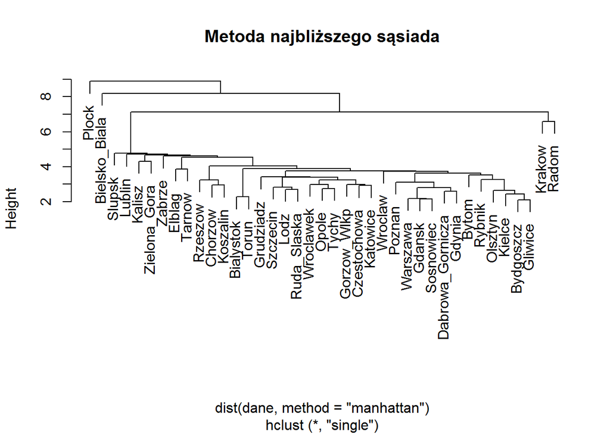

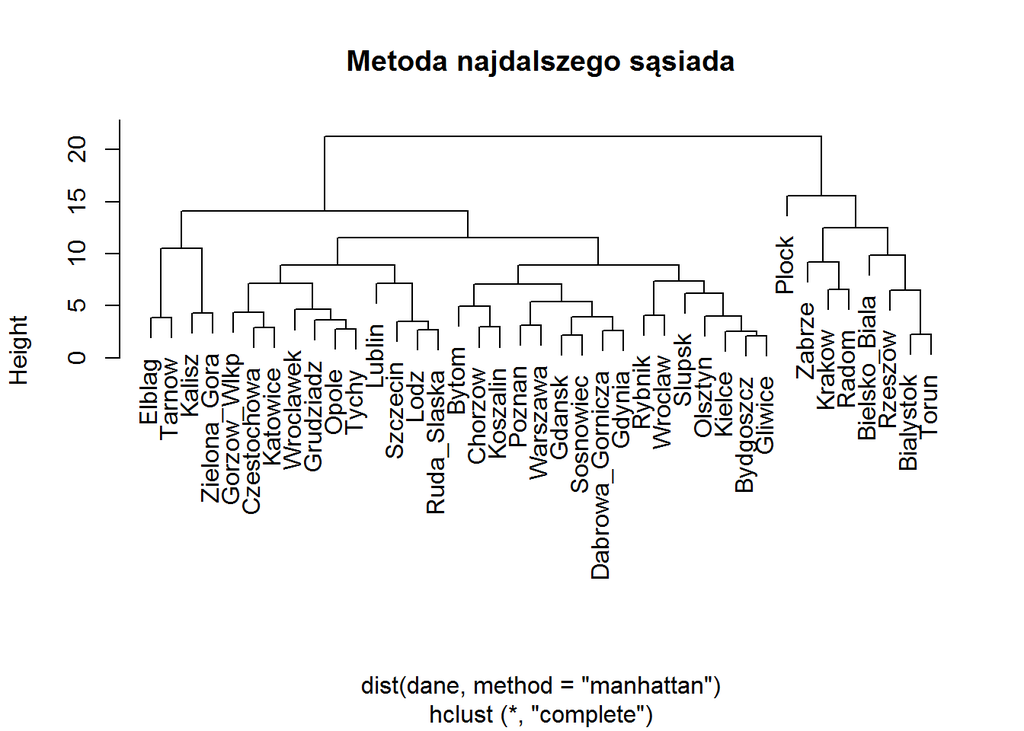

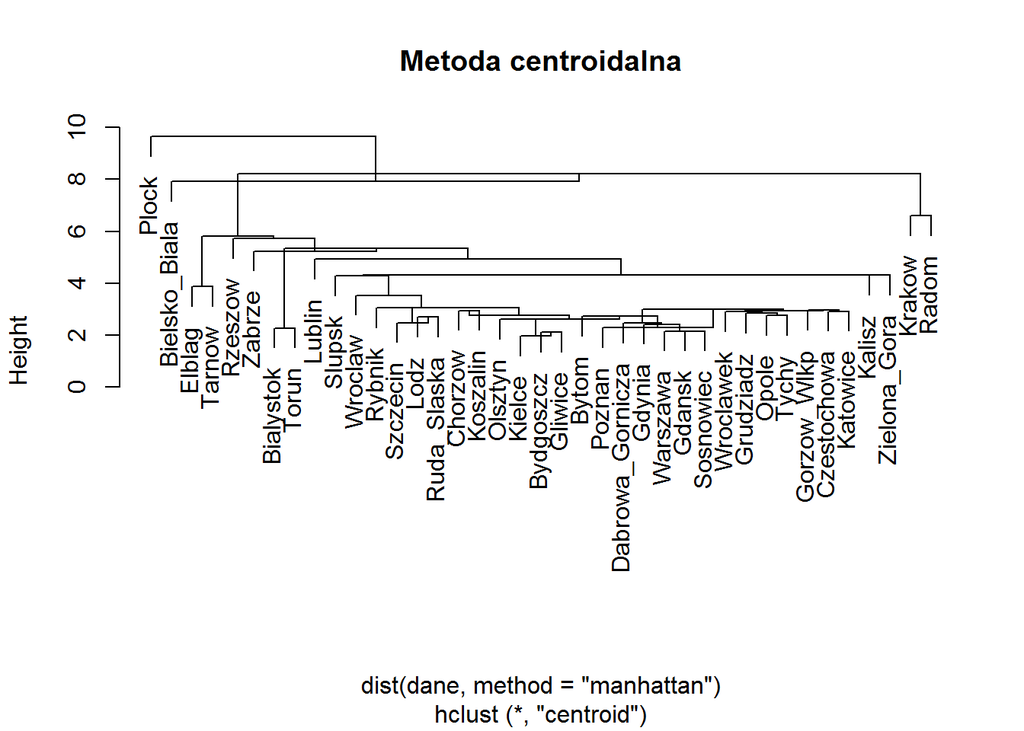

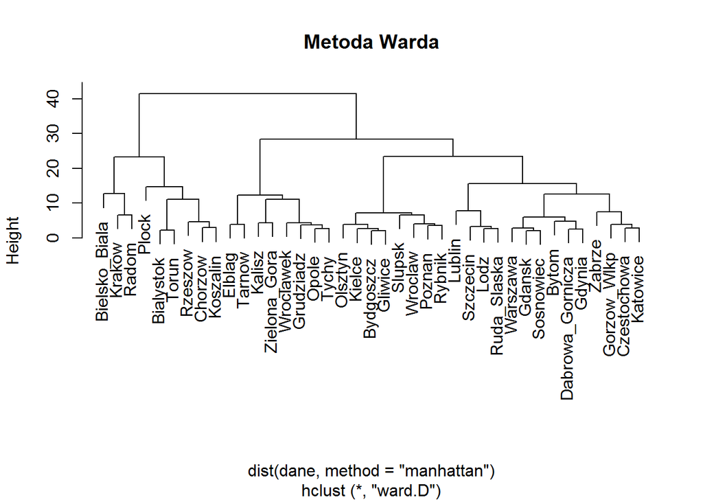

```r
plot(hclust(dist(dane, method = "manhattan"),"single"), main = "Metoda najbliższego sąsiada")
plot(hclust(dist(dane, method = "manhattan"),"complete"), main = "Metoda najdalszego sąsiada")
plot(hclust(dist(dane, method = "manhattan"),"centroid"), main = "Metoda centroidalna")
plot(hclust(dist(dane, method = "manhattan"),"ward.D"), main = "Metoda Warda")
```

Sytuacja wygląda podobnie jak przy metodzie euklidesowej, ponownie dwie metody są czytelne, a dwie nie. Zmienia się podział jeśli chodzi o większe grupy, jednak w mniejszych grupach wygląda to podobnie.  
Trzecią z miar odległości będzie odległość Minkowskiego (dla p = 3).

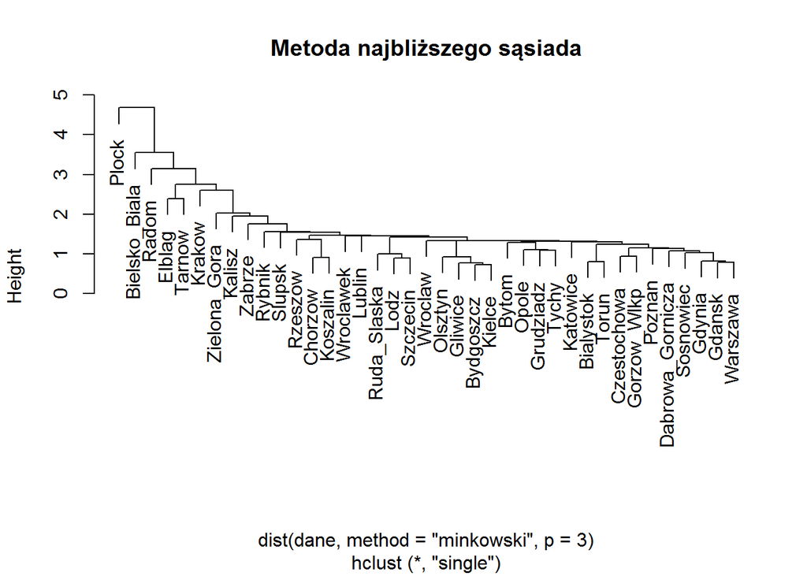

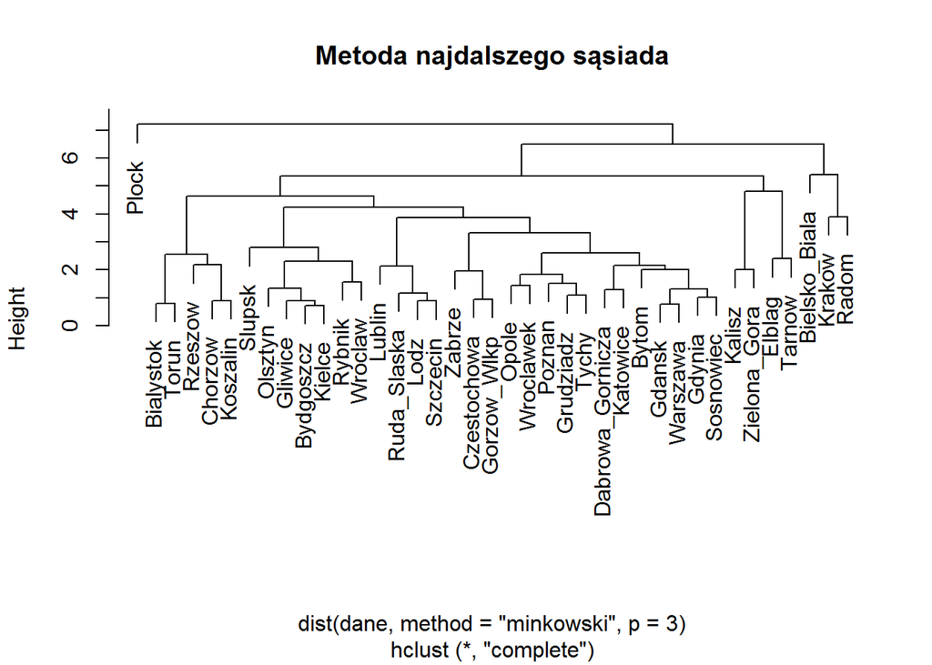

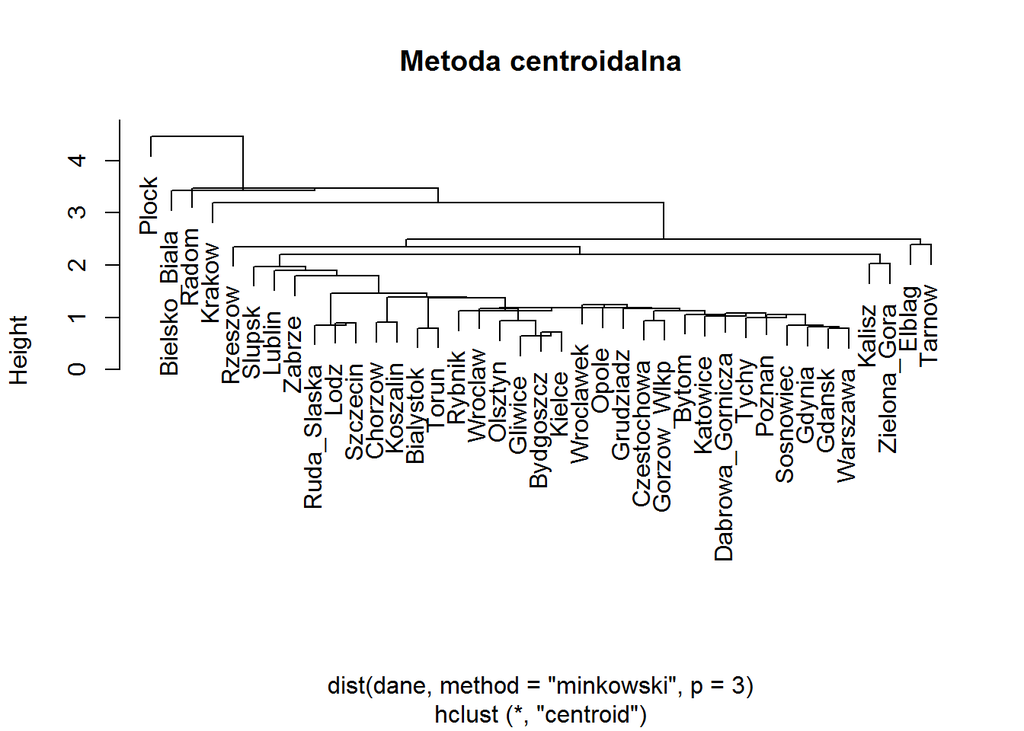

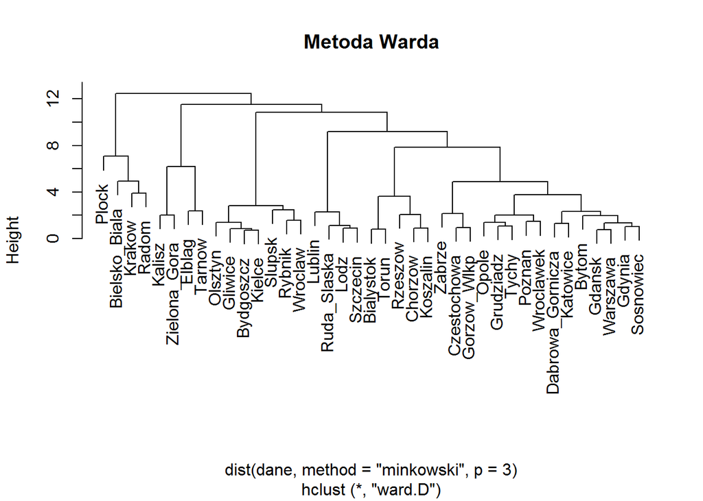

```r
plot(hclust(dist(dane, method = "minkowski", p = 3),"single"), main = "Metoda najbliższego sąsiada")
plot(hclust(dist(dane, method = "minkowski", p = 3),"complete"), main = "Metoda najdalszego sąsiada")
plot(hclust(dist(dane, method = "minkowski", p = 3),"centroid"), main = "Metoda centroidalna")
plot(hclust(dist(dane, method = "minkowski", p = 3),"ward.D"), main = "Metoda Warda")
```

Wydaje się, że odległość Minkowskiego jest najgorsza spośród wszystkich, każdy z wykresóW jest dość mocno spiętrzony, przez co trudno jest wydzielić pojedyńcze grupy.

## Podobieństwa i różnice

Jak to już zostało wspomniane, pokazane metody można podzielić na te łatwe do pogrupowania (metoda najdalszego sąsiada oraz Warda), jak i te, w których miasta są mocno spiętrzone (metoda najbliższego sąsiada i centroidalna). To są właśnie różnice i podobieństwa, które wpływają na to, którą metodę uznać za lepszą. Pod względem użytych miar odległości, poza odległością Minkowskiego, która daje spiętrzone dendogramy, nie ma sporej różnicy w klasyfikacji miast. Na potrzeby projektu zdecydowałem się na metodę Warda (częściej stosowana w praktyce niż metoda najdalszego sąsiada) oraz standardową odległość euklidesową.

## Omówienie ostatecznego wyniku

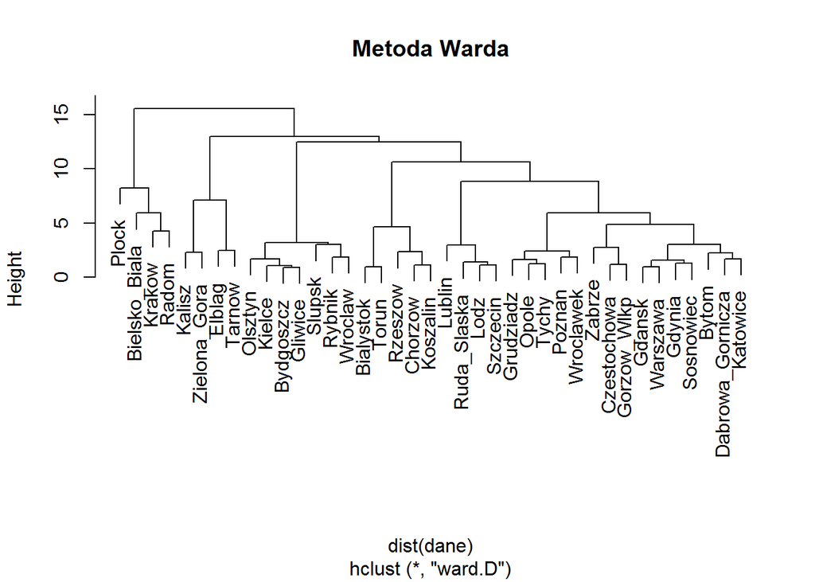

```r
plot(hclust(dist(dane),"ward.D"), main = "Metoda Warda")
```

### Podsumowanie

Można zauważyć, że działając różnymi metodami można dojść do podobnych wniosków. Daje się wyłonić miasta, które są najlepsze dla rowerzystów, jak i takie, które są dla nich najgorsze. Kluczem jest jednak wybór odpowiedniej metody jak i dobór np. miary odległości, które choć zbliżone, mogą dać odmienne rezultaty.